# How life expectancy change over time for each continent?

```r
library(tidyverse)
library(gapminder)
library(ggplot2)
```

### domanda 1

Ricavare una formula per calcolare l’aspettativa di vita di un continente

Per ciascun continente e per ogni anno, l’aspettativa di vita può essere calcolata come media ponderata: si moltiplica l’aspettativa di vita di ogni paese per la relativa popolazione, si sommano i prodotti ottenuti all’interno del continente e infine si divide il totale per la popolazione complessiva del continente stesso.

$$LE_{\text{continente}} =
\frac{\sum_{\text{paese} \in C} (LE_{\text{paese}} \times
Pop_{\text{paese}})}{\sum_{\text{paese} \in C}
Pop_{\text{paese}}}$$

```r
lifeExpContinenti <- gapminder |>
  mutate(lifepop = lifeExp * pop) |>
  group_by(continent, year) |>
   summarize(
     popTot = sum(pop),
     lifePopTot = sum(lifepop)
   ) |>
  mutate(lifeExpCont = lifePopTot/popTot) |>
  select(-lifePopTot, -popTot)

lifeExpContinenti
```

```
## # A tibble: 60 × 3
## # Groups:   continent [5]
##    continent  year lifeExpCont
##    <fct>     <int>       <dbl>
##  1 Africa     1952        38.8
##  2 Africa     1957        40.9
##  3 Africa     1962        43.1
##  4 Africa     1967        45.2
##  5 Africa     1972        47.2
##  6 Africa     1977        49.2
##  7 Africa     1982        51.0
##  8 Africa     1987        52.8
##  9 Africa     1992        53.4
## 10 Africa     1997        53.3
## # ℹ 50 more rows
```

### domanda 2

tracciare come l’aspettativa di vita è cambiata nel tempo per ciascun continente

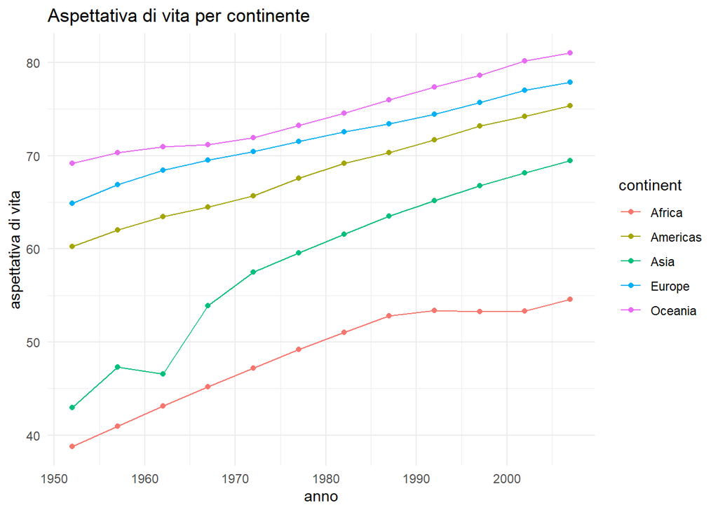

```r
plot <- ggplot(data = lifeExpContinenti,
               mapping = aes(x = year, y = lifeExpCont, color = continent)) +
  geom_line() +
  geom_point() +
  labs(
    title="Aspettativa di vita per continente",
    x="anno",
    y="aspettativa di vita"
  )+
  theme_minimal()

plot
```

Dal grafico si nota un aumento dell’aspettativa di vita globale tra il 1952 e il 2007, con l’Oceania che mantiene i valori più alti, seguita da Europa, Americhe, Asia e Africa. Tra i primi tre continenti il divario rimane pressoché costante nel tempo. L’Asia, che inizialmente registra valori molto bassi, a partire dagli anni ’60 mostra un forte incremento che la avvicina agli altri continenti. L’Africa, invece, rimane sui valori più bassi e tra la fine degli anni ’80 e il 2000 rimane costante.

### domanda 3

fai lo stesso per l’intero pianeta

```r
lifeExpPianeta <- gapminder |>
  mutate(lifepop = lifeExp * pop) |>
  group_by(year) |>
   summarize(
     popTot = sum(pop),
     lifePopTot = sum(lifepop)
   ) |>
  mutate(lifeExpPlanet = lifePopTot/popTot) |>
  select(-lifePopTot, -popTot)

lifeExpPianeta
```

```
## # A tibble: 12 × 2
##     year lifeExpPlanet
##    <int>         <dbl>
##  1  1952          48.9
##  2  1957          52.1
##  3  1962          52.3
##  4  1967          57.0
##  5  1972          59.5
##  6  1977          61.2
##  7  1982          62.9
##  8  1987          64.4
##  9  1992          65.6
## 10  1997          66.8
## 11  2002          67.8
## 12  2007          68.9
```

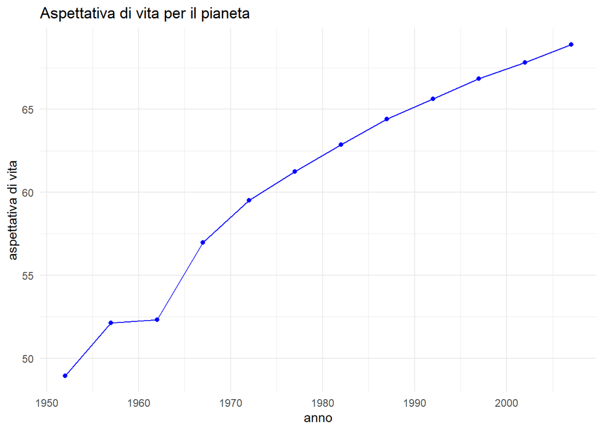

```r
plot2 <- ggplot(data = lifeExpPianeta,
               mapping = aes(x = year, y = lifeExpPlanet)) +
  geom_line(color = "blue") +
  geom_point(color = "blue") +
  labs(
    title="Aspettativa di vita per il pianeta",
    x="anno",
    y="aspettativa di vita"
  )+
  theme_minimal()

plot2
```